# How well do your senators represent your state’s support for Trump’s legislative agenda?

Tanner Gildea

2020-04-20

How often do your senators vote for Trump’s legislative agenda in the upper chamber? And how closely do they mirror your state’s popular support for Trump in the 2016 presidential election?

First, a quick refresher on the 2016 presidential election between Trump and Clinton. The figure below represents Trump’s percentage point margin over Clinton in each state.

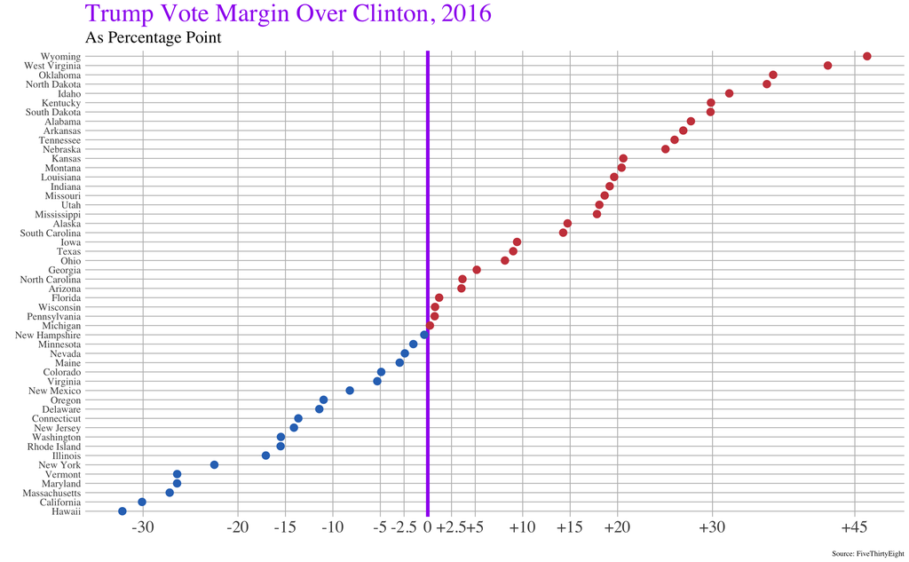

I’m looking at you, Michigan, Pennsylvania, Wisconsin.

Next, let’s look at each state’s senate delegation’s support for Trump’s legislative agenda.

How do we calculate this? Using data from [FiveThirtyEight](https://projects.fivethirtyeight.com/congress-trump-score/?ex_cid=rrpromo), I accessed the voting record for each senator, and whether Trump supported or opposed the vote. This information is current for the 115th and 116th Congresses, up through the Senate’s March 25, 2020 vote on H.R. 748 (the $2 trillion economic stimulus package in response to the coronavirus pandemic. Trump supported the bill).

Then, I grouped the senators’ voting records by state delegation and created a support percentage from the total number of votes cast in Trump’s favor. This metric accounts for changes in Senate representation and variance in the number of votes cast by each senator.

The figure below presents this Senate support metric for each state.

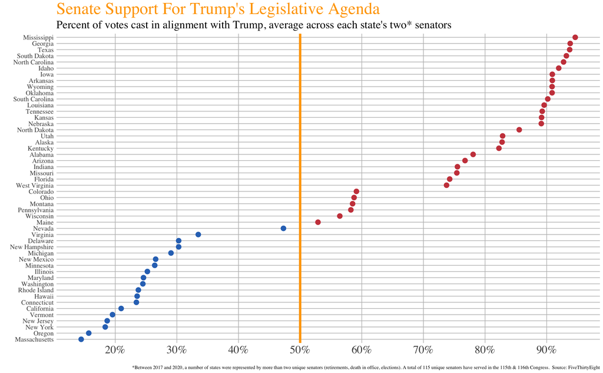

Not too many swing senate delegations, you’ll notice.

Now that we have Trump’s margin of victory in 2016 and the average support percentage from each state’s Senate delegation, we can observe how closely the two metrics align. To do so, I created a new “Representative Support Alignmentment” metric, visualized in the figure below.

To better understand this measurement, let’s take the state of Washington as an example. Trump lost the state in 2016 to Clinton by a 15.5 point margin (-15.5), and Washington’s senators vote with Trump’s agenda 24.5% of the time. The senators’ support margin is therefore -25.5 (24.5% minus 50%). The difference between Trump’s margin over Hillary (-15.5) and the senators’ support margin (-25.5) is -10.

This difference is the Representative Support Alignment metric: the more negative, the more liberal the state’s senate delegation relative to the state’s popular support for Trump in 2016; the more positive, the more conservative.

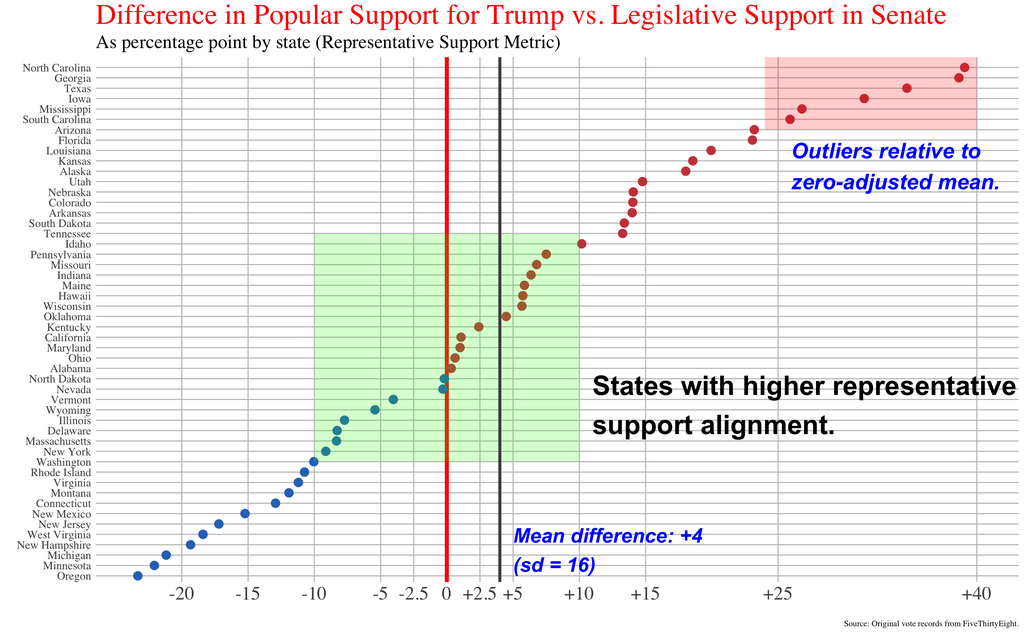

You’ll notice that only a minority of states have a Representative Support Alignment metric near zero. States near zero have senate delegations that support or oppose Trump’s legislative agenda at comporable rates to how their populations supported or opposed Trump in the 2016 election.

In theory, how liberal or conservative a state is should not impact how representative its senate delegation is. The states of Nevada, North Dakota, Alabama, Ohio, Maryland, California, and Kentucky run the ideological gamut, yet all have scores near zero. Trump’s legislative agenda is well supported or opposed by their senate delegations given their own specific constituents.

The consituents of states that have very positive or negative scores are less well represented in terms of Trump’s legislative agenda. As you see above, there are significant discrepancies on both sides of the aisle.

That said, significantly unaligned states (defined as 1.5 standard deviations above or below zero) all bend more conservative: South Carolina, Mississippi, Iowa, Texas, Georgia, and North Carolina. Voters in these states who opposed Trump in 2016 are hardly represented by their senators in relation to Trump’s agenda. Voters in these states who supported Trump in 2016 should be very happy with their Senate representation.

Here’s another way of looking at it: let’s visualize this metric across the continental United States below. States in white are well-represented. Bluer states are more liberally represented, while redder states are more conservatively represented.

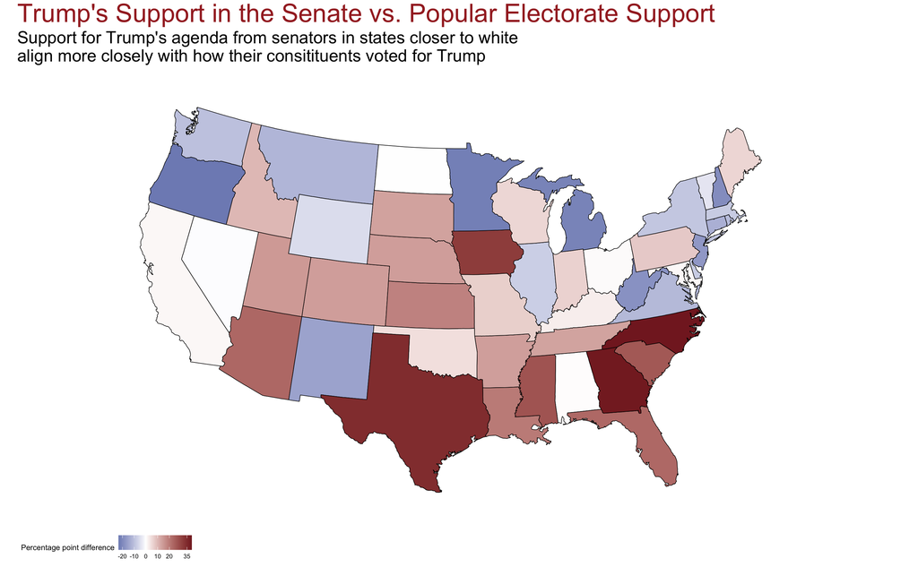

The figure below represents the same percentage point difference data as presented in the choropleth above. However, it also includes the states of Hawaii & Alaska (and I wanted to try using the novel “Shapebin” visualization). The more beige the state, the closer the alignment.

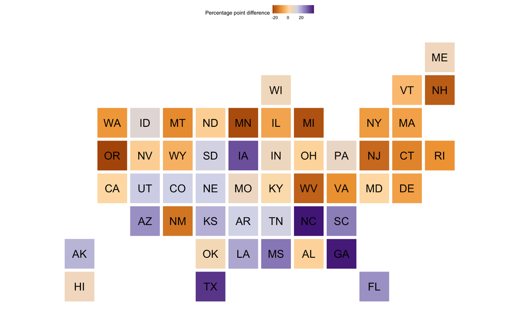

Of course, voters are generally only presented with a binary choice when it comes to the president and their senators. The individual voter cannot vote for x% of the president’s proposed agenda - and they cannot predict what parts of the presidential candidate’s agenda will actually be legislated if elected . And even if they could, which parts would they support or oppose?

The same is true for their senators. However, senators ARE able to vote on specific pieces of the president’s agenda, and they know to what degree their constituents supported or opposed the president in the aggregate.

From this analysis, it is clear that some senate delegations do a great job of representing their voting consituents in relation to Trump’s agenda. Other delegations say yes or no to the president more often than their constituents might like. And in the case of South Carolina, Mississippi, Iowa, Texas, Georgia, and North Carolina, Senators support Trump’s agenda significantly more than their voters supported Trump.

For some of the intermediate data I used to conduct this analysis and construct my visualizations, feel free to reference the state-specific table below. For a related dashboard focused on individual senators and some of the original datasets, please visit [FiveThirtyEight](https://projects.fivethirtyeight.com/congress-trump-score/?ex_cid=rrpromo). Enjoy!

**Trump's Support in the Senate vs. Popular Electorate Support**

Jan. 3, 2017 - Mar. 25, 2020

| State | Net Senate Agenda Support | Trump 2016 Margin | Difference |
| --- | --- | --- | --- |
| Alabama | 28.1 | 27.7 | 0.3 |
| Alaska | 32.8 | 14.7 | 18.0 |
| Arizona | 26.7 | 3.5 | 23.2 |
| Arkansas | 40.9 | 26.9 | 14.0 |
| California | -29.0 | -30.1 | 1.1 |
| Colorado | 9.1 | -4.9 | 14.0 |
| Connecticut | -26.6 | -13.6 | -12.9 |
| Delaware | -19.7 | -11.4 | -8.3 |
| Florida | 24.3 | 1.2 | 23.1 |
| Georgia | 43.8 | 5.2 | 38.7 |
| Hawaii | -26.4 | -32.2 | 5.7 |
| Idaho | 41.9 | 31.8 | 10.2 |
| Illinois | -24.8 | -17.1 | -7.7 |
| Indiana | 25.5 | 19.2 | 6.4 |
| Iowa | 40.9 | 9.4 | 31.5 |
| Kansas | 39.2 | 20.6 | 18.6 |
| Kentucky | 32.3 | 29.8 | 2.4 |
| Louisiana | 39.6 | 19.6 | 19.9 |
| Maine | 2.9 | -3.0 | 5.9 |
| Maryland | -25.4 | -26.4 | 1.0 |
| Massachusetts | -35.5 | -27.2 | -8.3 |
| Michigan | -21.0 | 0.2 | -21.2 |
| Minnesota | -23.6 | -1.5 | -22.1 |
| Mississippi | 44.6 | 17.8 | 26.8 |
| Missouri | 25.4 | 18.6 | 6.8 |
| Montana | 8.5 | 20.4 | -11.9 |
| Nebraska | 39.1 | 25.0 | 14.1 |
| Nevada | -2.7 | -2.4 | -0.3 |
| New Hampshire | -19.7 | -0.4 | -19.3 |
| New Jersey | -31.3 | -14.1 | -17.2 |
| New Mexico | -23.4 | -8.2 | -15.2 |
| New York | -31.6 | -22.5 | -9.1 |
| North Carolina | 42.7 | 3.7 | 39.1 |
| North Dakota | 35.5 | 35.7 | -0.2 |
| Ohio | 8.8 | 8.1 | 0.6 |
| Oklahoma | 40.9 | 36.4 | 4.5 |
| Oregon | -34.3 | -11.0 | -23.3 |
| Pennsylvania | 8.2 | 0.7 | 7.5 |
| Rhode Island | -26.3 | -15.5 | -10.7 |
| South Carolina | 40.2 | 14.3 | 25.9 |
| South Dakota | 43.2 | 29.8 | 13.4 |
| Tennessee | 39.3 | 26.0 | 13.3 |
| Texas | 43.7 | 9.0 | 34.7 |
| Utah | 32.8 | 18.1 | 14.8 |
| Vermont | -30.4 | -26.4 | -4.0 |
| Virginia | -16.5 | -5.3 | -11.2 |
| Washington | -25.5 | -15.5 | -10.0 |
| West Virginia | 23.8 | 42.2 | -18.4 |
| Wisconsin | 6.4 | 0.8 | 5.7 |
| Wyoming | 40.9 | 46.3 | -5.4 |